## **Numbat**

### Blamed on foxes

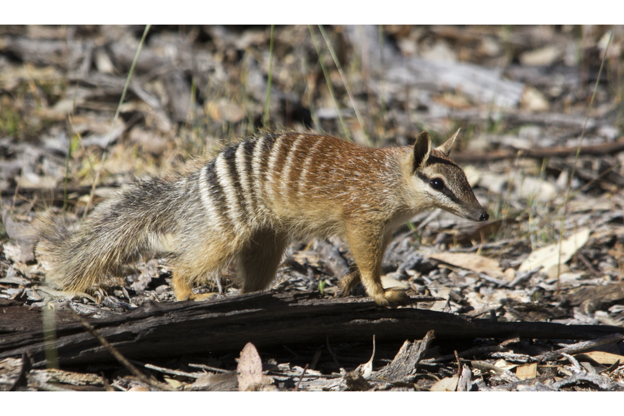

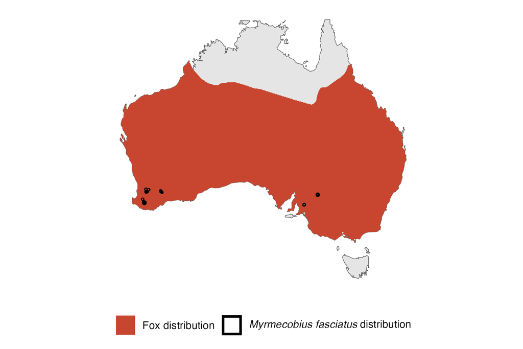

IUCN status: **Endangered**

EPBC Predator Threat Rating: **Very high/Extreme**

IUCN claim: *“The introduction of the predatory Red Fox and feral cats has had a profound impact and continues to be a major threat today (Friend 2008).”*

### Studies in support

A poison-baiting campaign initiated in 1982 was followed by a population increase (Friend 1990) until 1992 (Friend & Thomas 1994). Friend (1990) argued that numbat range contraction was more rapid in the arid zone during the 1940s and 1950s when foxes established in the area though no formal analysis was provided. Numbats were last confirmed in northwest SA, the Goldfields, central deserts, and the eastern and southwestern Wheatbelt 10-39, 10-15, 20-54, 40-64, and 28-64 years after foxes arrived, respectively (Wallach and Lundgren 2025).

### Studies not in support

The poison-baiting campaign that saw an initial population increase (1982-1992) was followed by a population crash (Friend & Page 2017). Foxes were not the main cause of mortality nor the main predator of reintroduced numbats (Friend & Thomas 1994). Numbats originally occurred across much of the southern half of Australia. Numbat distribution began to contract in the mid-1800s before foxes established (Friend 1990). Numbats were last confirmed in Adelaide 69-59 years before foxes arrived, and in the Western Division of NSW 10 years before, to 15 years after, foxes arrived (Wallach and Lundgren 2025).

### Is the threat claim evidence-based?

No studies were found evidencing a negative association between numbats and foxes. Poison-baiting is not a reliable proxy for fox abundance. In one region the extirpation record pre-dates the fox arrival record, and in another it cannot be verified that extirpation occured after fox arrival.

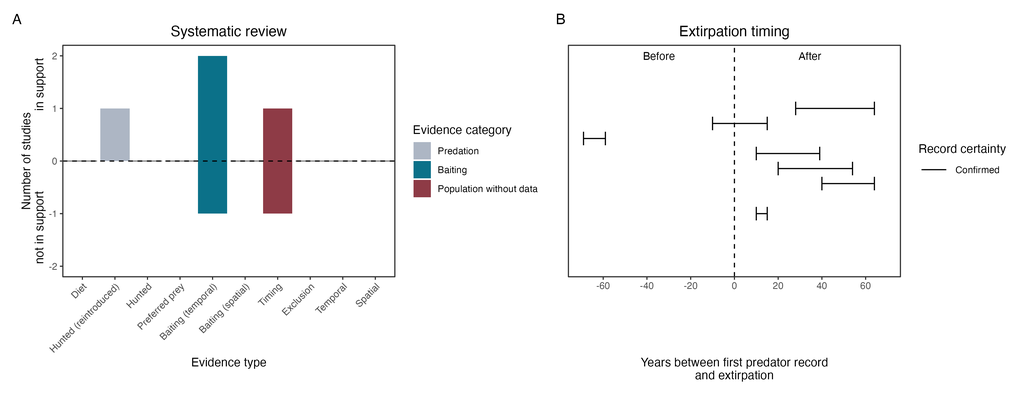

**Evidence linking *Myrmecobius fasciatus* to foxes.** **A.** Systematic review of evidence for an association between *Myrmecobius fasciatus* and foxes. Positive studies are in support of the hypothesis that foxes contribute to the decline of *Myrmecobius fasciatus*, negative studies are not in support. Predation studies include studies documenting hunting or scavenging; baiting studies are associations between poison baiting and threatened mammal abundance where information on predator abundance is not provided; population studies are associations between threatened mammal and predator abundance. Gold borders indicate studies that meet qualities of scientific rigour. **B.** Last records of extirpated populations relative to earliest local records of foxes. Error bars show minimum and maximum extinction intervals. Predator arrival records were digitized from Fairfax 2019. See methods section in Wallach and Lundgren 2025 for details on evidence categories.

### References

EPBC. (2015) Threat Abatement Plan for Predation by Feral Cats. Environment Protection and Biodiversity Conservation Act 1999, Department of Environment, Government of Australia. (Table A1).

Fairfax, Dispersal of the introduced red fox (Vulpes vulpes) across Australia. Biol. Invasions 21, 1259-1268 (2019).

Friend, J.A. and Thomas, N.D., 1994. Reintroduction and the numbat recovery programme. Reintroduction Biology of Australian and New Zealand Fauna’.(Ed. M. Serena.) pp, pp.189-198.

Friend, J.A., 1990. The numbat Myrmecobius fasciatus (Myrmecobiidae): history of decline and potential for recovery. In Proceedings of the Ecological Society of Australia (Vol. 16, pp. 369-377).

Friend, J.A., Page, M.J., 2017. Numbat (Myrmecobius fasciatus) Recovery Plan. Wildlife Management Program No. 60 in Department of Parks and Wildlife, Western Australia

IUCN Red List. https://www.iucnredlist.org/ Accessed June 2023

Wallach A.D., Lundgren E.J. (2025) Review of evidence that foxes and cats cause extinctions of Australia’s endemic mammals. BioScience. DOI: 10.1093/biosci/biaf046